# ACR_2Cvika.R

mcava

Thu Jan 24 10:39:18 2019

# Advanced Methods of Time Series Analysis Applied to Quarterly Estimates of Unemployment Rate

## 1. Elementary Modeling by an AR Process

We begin by extracting the data from a downloaded file

```r
setwd("D:/Martin Data/TimeSeriesAnalysis/ACR_2Repo")
dat <- read.table("LFS_unemployment.csv", header=F, skip=6, sep = ",", as.is = T)
dat <- dat[50:239,]
names(dat) <- c("quartile", "unemp")
dat$time <- dat$quartile[grepl('\\d{4}\\sQ\\d', dat$quartile)]

data.frame(head(dat$time)) # how the quarterly data looks
```

```
##   head.dat.time.
## 1        1971 Q1
## 2        1971 Q2
## 3        1971 Q3
## 4        1971 Q4
## 5        1972 Q1
## 6        1972 Q2
```

```r
months <- (as.numeric(gsub("\\d{4}\\sQ(\\d)","\\1", dat$time)) - 1) * 3
data.frame(head(months))
```

```
##   head.months.
## 1            0
## 2            3
## 3            6
## 4            9
## 5            0
## 6            3
```

```r
years <- as.numeric(gsub("(\\d{4})\\sQ\\d","\\1", dat$time))
data.frame(head(years))
```

```
##   head.years.
## 1        1971
## 2        1971
## 3        1971
## 4        1971
## 5        1972
## 6        1972
```

```r
years <- years + months / 12
data.frame(head(years)) # how the time data should look
```

```
##   head.years.
## 1     1971.00
## 2     1971.25
## 3     1971.50
## 4     1971.75
## 5     1972.00
## 6     1972.25
```

```r
dat$time <- years
```

### 1.1: Data Plot

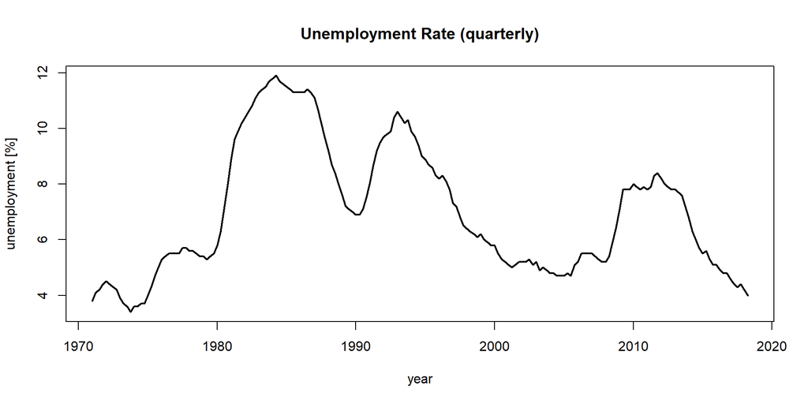

```r
plot(x=dat$time, y=dat$unemp, type="l", lwd=2, xlab="year", ylab = "unemployment [%]", main="Unemployment Rate (quarterly)")
```

### 1.2: Test Part and Evaluation Part of the Time Series

Now we separate the time series into test part, where a suitable model of a stochastic process will be found, and the evaluation part, where predictions given by such model are evaluated. Since our dataset contains quarterly data, we choose the length of the evaluation part of the time series as L = k * 4 where k is an arbitrary (and sufficiently small) positive integer.

```r
k = 5 # how many years
( L = k * 4 )
```

```
## [1] 20
```

```r
N = length(dat$unemp)
unempseries <- list(unempts = ts(dat$unemp))

unempseries$test = window(unempseries$unempts, start=1, end=N - L, extend=T)
unempseries$eval = window(unempseries$unempts, start=N - L + 1, end=N, extend=T)
```

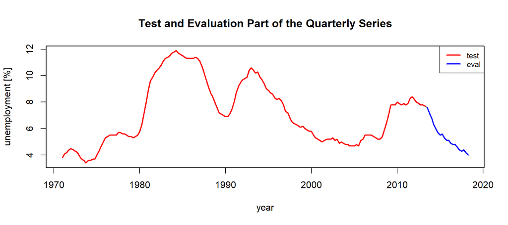

```r
par(mfrow=c(1,1))
plot(x=dat$time, y=dat$unemp, main="Test and Evaluation Part of the Quarterly Series", xlab="year", ylab="unemployment [%]",type="l")
lines(head(dat$time, n = N - L), unempseries$test, col="red", lwd=2)
lines(tail(dat$time, n = L), unempseries$eval, col="blue", lwd=2)
legend("topright", legend=c("test","eval"), col=c("red","blue"), lty=1, lwd=2, cex=0.8)
```

### 1.3: Mean, Variance, ACF, and PACF of the Test Part

```r
stat <- summary(as.numeric(dat$unemp)[1:(N - L)])
stddev <- var(unempseries$test, na.rm = TRUE)
v <- as.numeric(c(stat[1], stat[6], stat[4], stat[3], stddev))
names(v)<-c("Min.","Max.","Mean","Median","Variance")
v
```

```
##      Min.      Max.      Mean    Median  Variance
##  3.400000 11.900000  7.188824  6.900000  5.661827
```

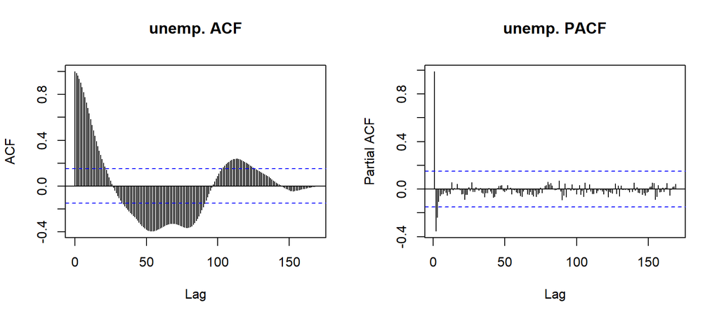

```r
par(mfrow=c(1,2))
acf(as.numeric(unempseries$test), lag.max=N, main="unemp. ACF")
acf(as.numeric(unempseries$test), lag.max=N, type="partial",main="unemp. PACF")
```

### 1.4: Finding a Suitable AR Model

Since the economic situation and the job market remembers its past, we choose a simple AR(p) process with parameter p corresponding to the number of steps after which the process still “remembers” its past. The inbuilt ar() function automatically finds the model with the lowest AIC (Akaike’s Information Criterion). And by plotting the $aic parameter we obtain differences AIC_min - AIC_k for all models.

```r
kmax = 30 # set a maximum order

model <- list()
model$ar<- ar(as.numeric(unempseries$test), order.max=kmax)
```

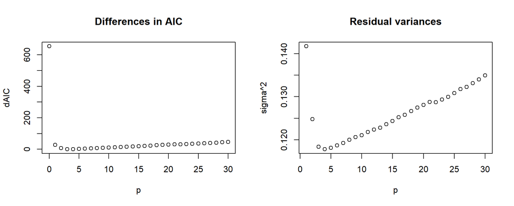

```r
par(mfrow=c(1,2))
plot(0:(length(model$ar$aic)-1), xlab="p", model$ar$aic, ylab="dAIC", main="Differences in AIC")
tmp <- sapply(1:kmax, function(x) ar(as.numeric(unempseries$test), aic=F, order.max=x)$var.pred)
plot( tmp, xlab="p", ylab="sigma^2", main="Residual variances")
```

```r
rbind(coef=model$ar$ar, se=sqrt(diag(model$ar$asy.var.coef)))
```

```
##           [,1]        [,2]       [,3]
## coef 1.2519124 -0.03440575 -0.2384831
## se   0.0753756  0.12294642  0.0753756
```

```r
( p <- model$ar$order )
```

```
## [1] 3
```

Unfortunately, the `ar` function does not return fitted values, thus we need to model the time series via the `arima` function using the AR order `p` from the previous result.

```r
suppressMessages(library(forecast))
( model$AR <- arima(as.numeric(unempseries$test), order=c(p, 0, 0)) )
```

```
##
## Call:
## arima(x = as.numeric(unempseries$test), order = c(p, 0, 0))
##
## Coefficients:
##          ar1      ar2      ar3  intercept
##       1.6000  -0.4176  -0.1951     6.8458
## s.e.  0.0752   0.1412   0.0754     0.9580
##
## sigma^2 estimated as 0.0289:  log likelihood = 56.88,  aic = -103.75
```

```r
unempseries$ARfit <- fitted(model$AR)
unempseries$ARresid <- residuals(model$AR)
```

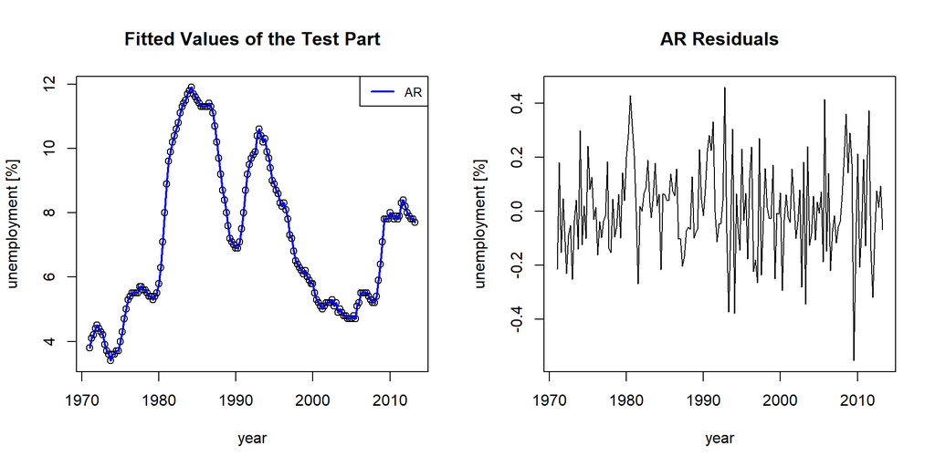

```r
par(mfrow=c(1,2))
plot(x=dat$time[1:(N - L)], y=unempseries$test,
     main="Fitted Values of the Test Part",
     xlab="year", ylab="unemployment [%]",type="p")
lines(x=dat$time[1:(N - L)], y=unempseries$test, col="blue", lwd=2)
legend("topright", legend=c("AR"), col=c("blue"), lty=1, lwd=2, cex=0.8)
plot(x=dat$time[1:(N - L)], y=unempseries$ARresid, main="AR Residuals", xlab="year", ylab="unemployment [%]", type="l")
```

The given AR model seems to fit the time series very well, which may be due to its low oscillation rate.

### 1.5: 1-Step Predictions Over the Evaluation Part

```r
tmp <- Arima(as.numeric(dat$unemp), model = model$AR)
model$ARpred <- window(fitted(tmp), start = N - L + 1)

( RMSE <- sqrt(mean((as.numeric(unempseries$eval) - as.numeric(model$ARpred))^2)) )
```

```
## [1] 0.1701227
```

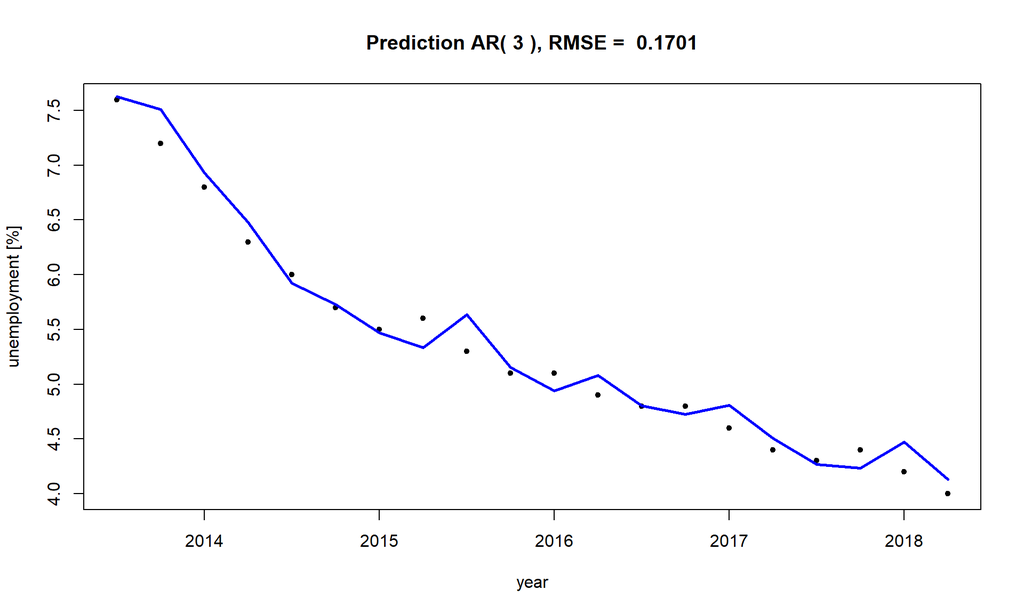

```r
par(mfrow=c(1,1))
plot(x=dat$time[(N - L + 1):N], y=dat$unemp[(N - L + 1):N],
     main=paste("Prediction AR(",p,"), RMSE = ",round(RMSE, digits = 4)),
     xlab="year", ylab="unemployment [%]",type="p", pch=20)
lines(x=dat$time[(N - L + 1):N], y=model$ARpred, lwd=2.5, col="blue")
```

## 2. Finding the Parameters of a SETAR Model

As we mentioned, the unemployment time series might be a result of a regime-switching process. Naturally, the behavior of the unemployment rate in a given country should depend on the current economic situation. The change in the local economy can be described via a set of “thresholds” which determine whether the stochastic process changes its regime. The regime of a stochastic process is defined as a unique ARMA or any other linear stochastic process with unique parameters. We begin by finding the parameters of a Self-Exciting Threshold Autoregressive (SETAR) process, that is: a process whose regime is described by a random variable determined by the very process itself, more specifically its history of up to d steps behind, which in an essence means that the process “influences its regime” up to d time steps into the future.

For the purposes of this analysis we consider only 2 regimes, namely the regime of “job crisis” when the unemployment rate may fluctuate or drop more wildly compared to the regime of “job stability” when the unemployment rate stabilizes or grows.

### 2.1: Implementation of Useful Functions

First we define a, so called, “indicator function” which essentially returns a boolean value from a given input process value `x` and threshold value `c`:

```r
Indicator <- function(x, c) ifelse(x > c, 1, 0)
```

Afterwards, we define the ‘basis’ function for a single regime

```r
Yt <- function(x, t, p) c(1, x[(t - 1):(t - p)])
```

which can then be used in the “basis” for two regimes:

```r
Xt <- function(x, t, p, d, c, z = x) {
  # z is the threshold variable
  I <- Indicator(z[t - d], c)
  Y <- Yt(x, t, p)
  c((1 - I) * Y, I * Y)
}
```

We can test the function on a given subset of the unemployment time series. Due to the fact that the examined time series is rather ‘smooth’, for further use, we will examine its differences:

```r
xt <- diff(as.numeric(dat$unemp))

d <- 1; t <- 3;
xt[(t - d): t]
```

```
## [1] 0.1 0.2
```

```r
Xt(xt, t, p, d, c = 0)
```

```
## [1] 0.0 0.0 0.0 1.0 0.1 0.3
```

```r
t <- 100;
xt[(t - d): t]
```

```
## [1] -0.3 -0.1
```

```r
Xt(xt, t, p, d, c = 0)
```

```
## [1]  1.0 -0.3 -0.1 -0.2  0.0  0.0  0.0  0.0
```

As we can see, in the first case, with time series values crossing zero from above, the latter half of the coefficient vector gets expressed, corresponding to the series assuming the second regime.

Then we need a function defining a deterministic skeleton of the model:

```r
SkeletonSETAR <- function(x, t, p, d, c, theta, z = x) theta %*% Xt(x, t, p, d, c, z)
```

where `theta` corresponds to the parameter vector, for example:

```r
SkeletonSETAR(xt, t, p, d, c = 0, c(1, 1, 1, 1, 1, 1, 1, 1))
```

```
##      [,1]
## [1,]  0.4
```

and the last group of functions we need for the upcoming procedure are functions for the information criteria of a SETAR model:

```r
# Akaike
AIC_SETAR <- function(orders, regimeDataCount, resVariances) {
  sum(regimeDataCount * log(resVariances) + 2 * (orders + 1))
}

# Bayesian
BIC_SETAR <- function(orders, regimeDataCount, resVariances) {
  sum(regimeDataCount * log(resVariances) + log(regimeDataCount) * (orders + 1))
}
```

and test it out:

```r
AIC_SETAR(c(2, 2), c(10, 10), c(0.5, 0.7))
```

```
## [1] 1.501779
```

```r
BIC_SETAR(c(2, 2), c(10, 10), c(0.5, 0.7))
```

```
## [1] 3.317289
```

### 2.2: The Estimation of Parameters of a SETAR Model

Given a dataset `x` and parameters `p` (AR order), `d` (SETAR delay), and the threshold `c` we find the coefficients of a SETAR model with these parameters by performing a multivariate linear regression. The coefficient vector`PhiParams` is the vector of unknowns of a linear system with matrix `X` and a right-hand-side vector `y` given by the time series. Although for higher values of `p` the inversion of matrix `X'X` (with dimensions `(2*p + 2)`x`(2*p + 2)`) might be computationally demanding, we will determine the covariance matrix, i.e.: `(X'X)^(-1)` using a function `inv` from the `matlib` package:

```r
suppressMessages(library(matlib))

EstimSETAR <- function(x, p, d, c) {
  resultModel <- list()
  resultModel$p = p; resultModel$d = d; resultModel$c = c;
  resultModel$data = x;  n = length(x);  resultModel$n = n;
  k <- max(p, d)

  X <- as.matrix(apply(as.matrix((k + 1):n), MARGIN=1, function(t) Xt(x, t, p, d, c) ))
  y <- as.matrix(x[(k + 1):n])

  A = crossprod(t(X), t(X));  b = crossprod(t(X), y)

  if (abs(det(A)) > 0.000001) {
    inv <- inv(A)
    solution <- cbind(as.numeric(t(inv %*% b)),  se =  sqrt(diag(inv)/n))

    resultModel$PhiParams <- solution[,1] # solving (X'X)*phi = X'y
    resultModel$PhiStErrors <- solution[,2]  # standard errors
    skel <- crossprod(X, resultModel$PhiParams); resultModel$skel <- skel;
    resultModel$residuals <- (y - skel)
    resultModel$resSigmaSq <- 1 / (n - k) * sum(resultModel$residuals ^ 2)

    return(resultModel)
  } else {
    return(NA)
  }
}
```

After performing this procedure for multiple parameters, i.e.: searching the discrete parameter space, we further process the model with minimum residual square sum. For that we’ll use:

```r
EstimSETAR_postproc <- function(model) {
  x <- model$data; k <- max(model$p, model$d); c <- model$c; n <- model$n;
  y <- as.matrix(x[(k + 1):n])
  skel <- model$skel; model$skel <- NULL; #skel attribute no longer needed

  model$n1 <- sum(apply(as.matrix(x), MARGIN = 1, function(xt) (1 - Indicator(xt, c))))
  model$n2 <- sum(apply(as.matrix(x), MARGIN = 1, function(xt) Indicator(xt, c)))

  model$resSigmaSq1 <- sum(
    apply(as.matrix(seq_along(y)), MARGIN = 1,
          function(t) ifelse((1 - Indicator(y[t], c)), (y[t] - skel[t])^2, 0))) / (model$n1 - k)
  model$resSigmaSq2 <- sum(
    apply(as.matrix(seq_along(y)), MARGIN = 1,
          function(t) ifelse(Indicator(y[t], c), (y[t] - skel[t])^2, 0))) / (model$n2 - k)

  model$AIC <- AIC_SETAR(c(p, p), c(model$n1, model$n2), c(model$resSigmaSq1, model$resSigmaSq2))
  model$BIC <- BIC_SETAR(c(p, p), c(model$n1, model$n2), c(model$resSigmaSq1, model$resSigmaSq2))

  return(model)
}
```

and now we test the function for suitable parameters:

```r
model <- EstimSETAR(xt, 2, 2, c=0)
str( model <- EstimSETAR_postproc(model) )
```

```
## List of 15
##  $ p          : num 2
##  $ d          : num 2
##  $ c          : num 0
##  $ data       : num [1:189] 0.3 0.1 0.2 0.1 -0.1 ...
##  $ n          : int 189
##  $ PhiParams  : num [1:6] 0.00468 0.41791 0.3983 0.06698 0.82465 ...
##  $ PhiStErrors: num [1:6] 0.0101 0.0465 0.0598 0.0145 0.0414 ...
##  $ residuals  : num [1:187, 1] 0.1021 -0.1147 -0.2151 -0.0673 -0.0231 ...
##  $ resSigmaSq : num 0.028
##  $ n1         : num 119
##  $ n2         : num 70
##  $ resSigmaSq1: num 0.0222
##  $ resSigmaSq2: num 0.0387
##  $ AIC        : num -665
##  $ BIC        : num -645
```

It should be noted that for some values of `p` and `d` the indices of arrays in the algorithms might get out of the range of regularity for the linear system. For that reason we implement exceptions for the outputs of `EstimSETAR` in the following algorithm.

### 2.3: SETAR Parameter Estimation Procedure

To answer the question: ‘how does one find the right parameters `p`, `d` and `c` for their desired SETAR model?’, we implement the following procedure:

```r
pmax <- 7 # set maximum order p
# limit the c parameter by the 7.5-th and 92.5 percentile
cmin <- as.numeric(quantile(xt, 0.075)); cmax <- as.numeric(quantile(xt, 0.925));
h = (cmax - cmin) / 100 # determine the step by which c should be iterated

models <- list()
modelColumns <- list()
for (p in 1:pmax) {
  for (d in 1:p) {
    pdModels <- list()
    for (c in seq(cmin, cmax, h)) {
      tmp <- EstimSETAR(xt, p, d, c) # try to run the function
      # then test whether it returns`NA` as a result
      if (!as.logical(sum(is.na(tmp))) ) {
        pdModels[[length(pdModels) + 1]] <- tmp
      }
    }
    sigmas <- as.numeric(lapply(pdModels, function(m) m$resSigmaSq))
    orders <- order(sigmas)
    # only the model whose parameter c gives the lowest residual square sum is chosen for postprocessing
    min_sigma_model <- EstimSETAR_postproc(pdModels[[ orders[1] ]])
    models[[length(models) + 1]] <- min_sigma_model
    modelColumns[[length(modelColumns) + 1]] <- c(
      p, d, min_sigma_model$c,
      min_sigma_model$n1, min_sigma_model$n2,
      min_sigma_model$AIC, min_sigma_model$BIC,
      min_sigma_model$resSigmaSq)
  }
}
modelColumns <- data.frame(matrix(unlist(modelColumns), nrow=length(modelColumns), byrow=T))
names(modelColumns) <- c(
  "p", "d", "c",
  "n1", "n2", "AIC", "BIC",
  "resSigmaSq"
)

head(modelColumns, n=12)
```

```
##    p d       c  n1  n2       AIC       BIC resSigmaSq
## 1  1 1  0.0050 119  70 -665.1401 -655.0849 0.02946193
## 2  2 1  0.4000 176  13 -666.9127 -655.7064 0.02824860
## 3  2 2  0.1077 148  41 -680.9611 -666.8288 0.02660428
## 4  3 1  0.4000 176  13 -665.7311 -650.7893 0.02739760
## 5  3 2  0.1077 148  41 -675.9433 -657.1001 0.02642112
## 6  3 3 -0.1925  47 142 -664.4361 -645.2122 0.02714186
## 7  4 1  0.3052 172  17 -679.5906 -659.6871 0.02587450
## 8  4 2  0.1077 148  41 -671.0509 -647.4970 0.02640513
## 9  4 3 -0.1925  47 142 -660.1140 -636.0841 0.02707459
## 10 4 4  0.3052 172  17 -673.5321 -653.6286 0.02676427
## 11 5 1  0.3052 172  17 -676.6317 -652.7475 0.02555036
## 12 5 2  0.4000 176  13 -669.2849 -646.8723 0.02595580
```

Now we have a set of models in their original order. To find the best suitable model, we choose 12 models with the lowest BIC (Bayesian Information Criterion):

```r
BICs <- sapply(models, function(m) m$BIC)
orders <- order(BICs)
modelColumns <- modelColumns[orders,]

head(modelColumns, n=12)
```

```
##    p d      c  n1 n2       AIC       BIC resSigmaSq
## 3  2 2 0.1077 148 41 -680.9611 -666.8288 0.02660428
## 7  4 1 0.3052 172 17 -679.5906 -659.6871 0.02587450
## 5  3 2 0.1077 148 41 -675.9433 -657.1001 0.02642112
## 2  2 1 0.4000 176 13 -666.9127 -655.7064 0.02824860
## 1  1 1 0.0050 119 70 -665.1401 -655.0849 0.02946193
## 10 4 4 0.3052 172 17 -673.5321 -653.6286 0.02676427
## 11 5 1 0.3052 172 17 -676.6317 -652.7475 0.02555036
## 4  3 1 0.4000 176 13 -665.7311 -650.7893 0.02739760
## 14 5 4 0.3052 172 17 -672.4772 -648.5929 0.02619708
## 8  4 2 0.1077 148 41 -671.0509 -647.4970 0.02640513
## 16 6 1 0.3052 172 17 -674.9944 -647.1294 0.02494000
## 12 5 2 0.4000 176 13 -669.2849 -646.8723 0.02595580
```

and we can also include errors of the estimated regression coefficients:

```r
modelCoeffErrors <- list()
for(i in 1:12) {
  p <- models[[ orders[i] ]]$p
  d <- models[[ orders[i] ]]$d
  c <- models[[ orders[i] ]]$c
  key <- paste(p, d, round(c, digits=4), sep="/")
  modelCoeffErrors[[key]] <- rbind(t(models[[ orders[i] ]]$PhiParams), t(models[[ orders[i] ]]$PhiStErrors))
  row.names(modelCoeffErrors[[key]]) <- t(c("Phi", "stdError"))
}
modelCoeffErrors
```

```
## $`2/2/0.1077`
##                 [,1]      [,2]       [,3]       [,4]       [,5]
## Phi      0.003935039 0.4470165 0.37460889 0.09138806 1.08026643
## stdError 0.007209393 0.0365959 0.04350063 0.02448193 0.05596549
##                 [,6]
## Phi      -0.42454326
## stdError  0.07400055
##
## $`4/1/0.3052`
##                  [,1]       [,2]      [,3]       [,4]        [,5]
## Phi      -0.010415511 0.52539612 0.1957427 0.04672256 -0.02925102
## stdError  0.005934234 0.03864105 0.0386562 0.03772528  0.03251886
##                [,6]      [,7]      [,8]        [,9]      [,10]
## Phi      -0.1503804 0.9452945 0.7317165 -0.00962392 -1.2916701
## stdError  0.0752047 0.1729742 0.1539349  0.18709846  0.1508923
##
## $`3/2/0.1077`
##                 [,1]       [,2]       [,3]       [,4]       [,5]
## Phi      0.004390532 0.42513468 0.33722534 0.07776119 0.08019403
## stdError 0.007212687 0.03806445 0.04703535 0.03721094 0.02484264
##                [,6]        [,7]        [,8]
## Phi      1.07869738 -0.31056937 -0.11792864
## stdError 0.05656146  0.09454831  0.05985791
##
## $`2/1/0.4`
##                  [,1]       [,2]       [,3]       [,4]      [,5]
## Phi      -0.009219145 0.53083128 0.21718321 0.12192270 1.0454693
## stdError  0.005667068 0.03470835 0.03175163 0.09169256 0.1855723
##                [,6]
## Phi      -0.4524196
## stdError  0.1142802
##
## $`1/1/0.005`
##                [,1]       [,2]        [,3]       [,4]
## Phi      0.01546129 0.77306739 -0.08385375 0.96647682
## stdError 0.01002553 0.04785017  0.01408073 0.04124099
##
## $`4/4/0.3052`
##                 [,1]       [,2]       [,3]         [,4]        [,5]
## Phi      0.003008156 0.64727127 0.34615949 -0.001935334 -0.13921134
```

[output cut: 49 more lines]

```
## stdError  0.03756245 0.03229420  0.07531283 0.1744944 0.1724276 0.2312489
##               [,12]      [,13]     [,14]
## Phi      -1.2337987 -1.3193475 1.0035981
## stdError  0.2012617  0.3471732 0.2212055
##
## $`5/2/0.4`
##                 [,1]       [,2]       [,3]       [,4]        [,5]
## Phi      0.008827409 0.56317724 0.33554848 0.06772248 0.003419416
## stdError 0.005764781 0.03442075 0.04025729 0.03925878 0.037310714
##                 [,6]       [,7]      [,8]       [,9]     [,10]      [,11]
## Phi      -0.13179682 -0.1524130 1.0901812 -0.3637433 1.5156794 -2.2827994
## stdError  0.03218798  0.1040857 0.1279548  0.2171671 0.2280857  0.3190015
##              [,12]
## Phi      1.0286716
## stdError 0.2884208
```

We can now visualize the results of the top 3 models:

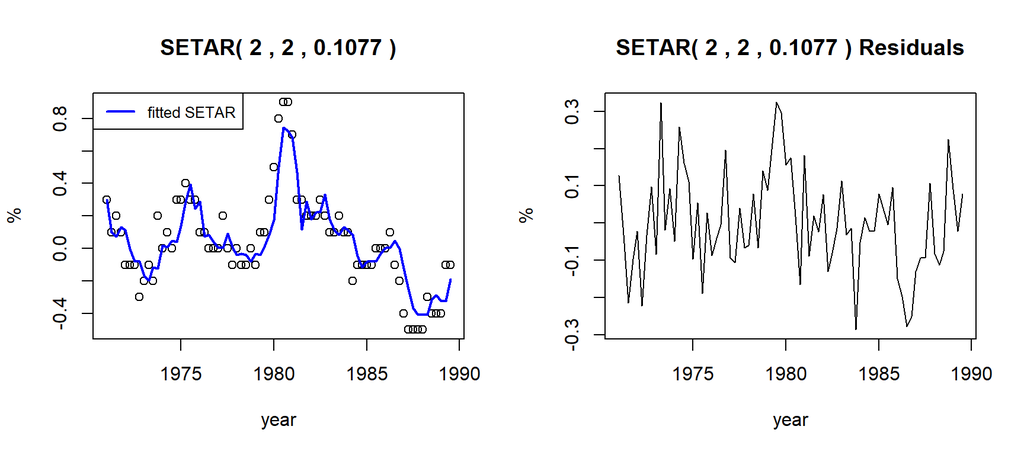

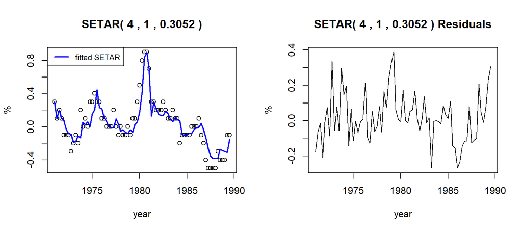

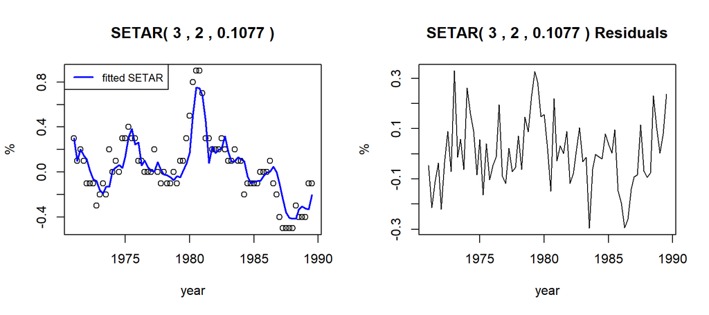

```r
plotNmax <- 75
par(mfrow=c(1,2))
for (i in 1:3) {
  model <- models[[orders[i]]]
  SetarFit <- xt - append(matrix(0., ncol=model$p), model$residuals)
  m <- length(model$residuals)

  plot(x=dat$time[1:plotNmax], y=xt[1:plotNmax],
       main=paste("SETAR(",model$p,",",model$d,",",round(model$c, digits=4),")"), xlab="year", ylab="%")
  lines(x=dat$time[1:plotNmax], y=SetarFit[1:plotNmax], col="blue",lwd=2)
  legend("topleft", legend=c("fitted SETAR"), col=c("blue"), lty=1, lwd=2, cex=0.8)

  plot(x=dat$time[1:plotNmax], y=model$residuals[1:plotNmax], type="l", main=paste("SETAR(",model$p,",",model$d,",",round(model$c, digits=4),") Residuals"),
       xlab="year", ylab="%")
}
```

The results suggest that the best SETAR models have a threshold `c` quite close to zero and more-or-less the same RSS. The very first with a lower `BIC` (Bayesian Information Criterion), has slightly larger RSS than the models that come after it. To verify the correctness of our procedure we will need to compare it with inbuilt functions from a verified library.

### 2.4: SETAR Equilibrium Simulations

It is also essential to find out whether the skeletons of the selected SETAR models have some equilibria. We are going to find out by simulating trajectories of the top 3 models selected in the previous section:

```r
par(mfrow=c(1,1))
```

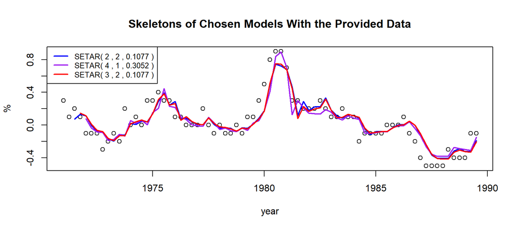

```r
plot(x=dat$time[1:plotNmax], y=xt[1:plotNmax],
     main="Skeletons of Chosen Models With the Provided Data", xlab="year", ylab="%")
for (i in 1:3) {
  s <- array()
  k <- max(models[[orders[i]]]$p, models[[orders[i]]]$d)
  for (t in (k + 1):plotNmax) {
    tmp <- try(SkeletonSETAR(xt, t, models[[orders[i]]]$p, models[[orders[i]]]$d, models[[orders[i]]]$c, t(models[[orders[i]]]$PhiParams)),
               silent=T)
    if (class(tmp) == "try-error") {
      s[t - k] <- NA
    } else {
      s[t - k] <- tmp
    }
  }
  lines(x=dat$time[(k + 1):plotNmax], y=s[1:(plotNmax - k)], col=c("blue","purple","red")[i],lwd=2)
}
legend("topleft", legend=c(paste("SETAR(",models[[orders[1] ]]$p,",",models[[orders[1] ]]$d,",",round(models[[orders[1] ]]$c, digits=4),")"),
                           paste("SETAR(",models[[orders[2] ]]$p,",",models[[orders[2] ]]$d,",",round(models[[orders[2] ]]$c, digits=4),")"),
                           paste("SETAR(",models[[orders[3] ]]$p,",",models[[orders[3] ]]$d,",",round(models[[orders[3] ]]$c, digits=4),")")),
       col=c("blue","purple","red"), lty=1, lwd=2, cex=0.8)
```

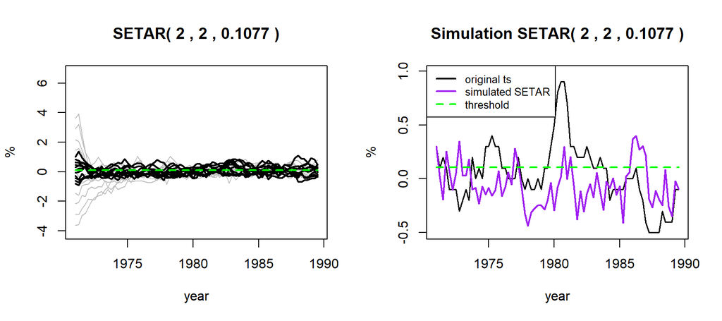

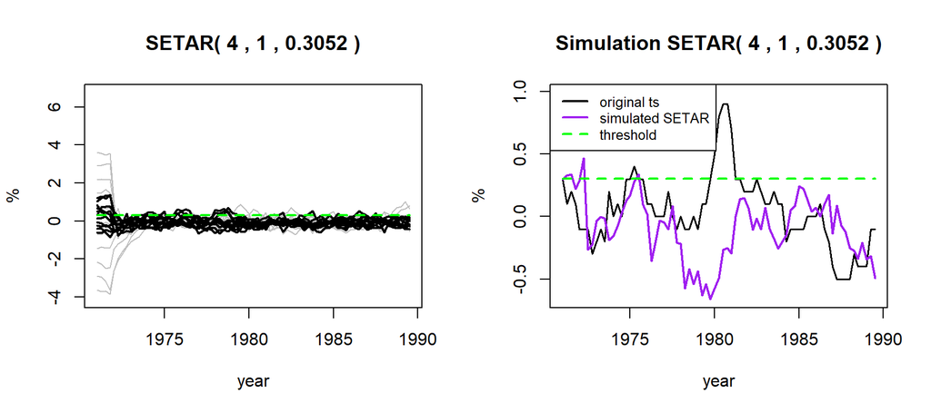

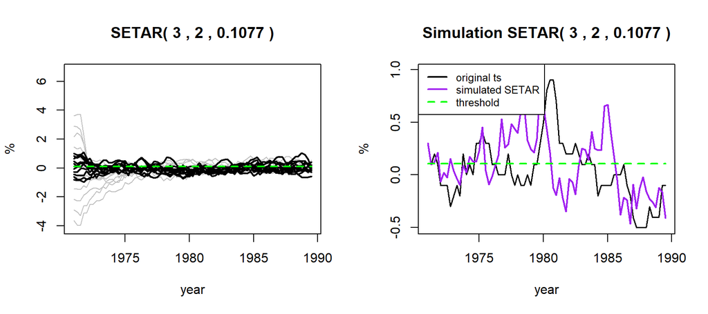

```r
xmax <- 5 * max(xt); xmin <- min(xt) - 0.5 * xmax;
xmax0 <- max(xt); xmin0 <- min(xt)
par(mfrow=c(1,2))
for (i in 1:3) {
  equilib_sims <- list()
  p <- models[[orders[i] ]]$p; d <- models[[orders[i] ]]$d; c <- models[[orders[i] ]]$c;
  sigmaSq <- models[[orders[i] ]]$resSigmaSq
  k <- max(p, d)
  n_offsets <- 10
  for (j in 0:n_offsets) {
    x0 <- (xmax - xmin) / n_offsets * j - 0.5 * (xmax - xmin)
    equilib_sim <- array()
    equilib_sim[1] <- x0
    for (t in 2:plotNmax) {
      if (t < (k + 1)) {
        equilib_sim[t] <- equilib_sim[t - 1] + rnorm(1, 0, sqrt(sigmaSq))
      } else {
        equilib_sim[t] <- SkeletonSETAR(equilib_sim, t, p, d, c, t(models[[orders[i]]]$PhiParams)) + rnorm(1, 0, sqrt(sigmaSq))
      }
    }
    equilib_sims[[j + 1]] <- equilib_sim
    if (j < 1) {
      plot(x=dat$time[1:plotNmax], y=equilib_sim, type="l", col="gray", ylim=c(1.5 * xmin, 1.5 * xmax),
           main=paste("SETAR(",models[[orders[i] ]]$p,",",models[[orders[i] ]]$d,",",round(models[[orders[i] ]]$c, digits=4),")"),
           xlab="year", ylab="%")
    } else {
      lines(x=dat$time[1:plotNmax], y=equilib_sim, col="gray")
    }
  }
  for (j in 0:n_offsets) {
    epsilon <- (xmax - xmin) * 0.025
    x0 <- c + (n_offsets / 2 - j) * epsilon #small initial perturbations from the threshold value
    equilib_sim <- array()
    equilib_sim[1] <- x0
    for (t in 2:plotNmax) {
      if (t < (k + 1)) {
        equilib_sim[t] <- equilib_sim[t - 1] + rnorm(1, 0, sqrt(sigmaSq))
      } else {
        equilib_sim[t] <- SkeletonSETAR(equilib_sim, t, p, d, c, t(models[[orders[i]]]$PhiParams)) + rnorm(1, 0, sqrt(sigmaSq))
      }
    }
    equilib_sims[[j + 1]] <- equilib_sim
    lines(x=dat$time[1:plotNmax], y=equilib_sim, lwd=2)
    lines(x=c(dat$time[1], dat$time[plotNmax]), y=c(c, c), col="green", lty="dashed", lwd=2)
  }
  # comparison of the original data with the simulation of the original time series

  x0 <- xt[1]
  equilib_sim <- array()
  equilib_sim[1] <- x0
  for (t in 2:plotNmax) {
    if (t < (k + 1)) {
      equilib_sim[t] <- equilib_sim[t - 1] + rnorm(1, 0, sqrt(sigmaSq))
    } else {
      equilib_sim[t] <- SkeletonSETAR(equilib_sim, t, p, d, c, t(models[[orders[i]]]$PhiParams)) + rnorm(1, 0, sqrt(sigmaSq))
    }
  }
  simMax <- max(equilib_sim, xmax0); simMin <- min(equilib_sim, xmin0);
  plot(x=dat$time[1:plotNmax], y=xt[1:plotNmax], type="l", lwd=1.5, ylim=c(simMin, 1.1 * simMax),
       main=paste("Simulation SETAR(",models[[orders[i] ]]$p,",",models[[orders[i] ]]$d,",",round(models[[orders[i] ]]$c, digits=4),")"),
       xlab="year", ylab="%")
  lines(x=dat$time[1:plotNmax], y=equilib_sim, col="purple", lwd=2, )
  lines(x=c(dat$time[1], dat$time[plotNmax]), y=c(c, c), col="green", lty="dashed", lwd=2)
  legend("topleft", legend=c("original ts","simulated SETAR","threshold"), col=c("black","purple","green"), lty=c(1,1,2), lwd=2, cex=0.8)
}
```

The trajectories of all of the first three models seem to gravitate toward `0` significantly fast (or alternatively: towards their threshold values which are close to zero as well). The relatively low oscillation rate of the original time series suggests that the differences of this time series will, at most, fluctuate around 0. The change between the ‘high’ and ‘low’ regimes does not seem very significant, at leat on the larger scale. The validity of the model will be tested in chapter 3.

### 2.5: Comparison Of the Results With Inbuilt Functions

To verify the correctness of our methods we proceed to construct the top 3 SETAR models by plugging their parameters into inbuilt functions:

```r
suppressMessages(library(tsDyn))
```

Testing a function which selects an orders automatically:

```r
mmax <- 2
```

```r
par(mfrow=c(1,1))
( result1 <- selectSETAR(xt, m=mmax, thDelay=0:(mmax-1), criterion="BIC", same.lags=T, trim=0.1)  )
```

```
## Using maximum autoregressive order for low regime: mL = 2
## Using maximum autoregressive order for high regime: mH = 2
## Searching on 20 possible threshold values within regimes with sufficient ( 10% ) number of observations
## Searching on  80  combinations of thresholds ( 20 ), thDelay ( 2 ) and m ( 2 )
```

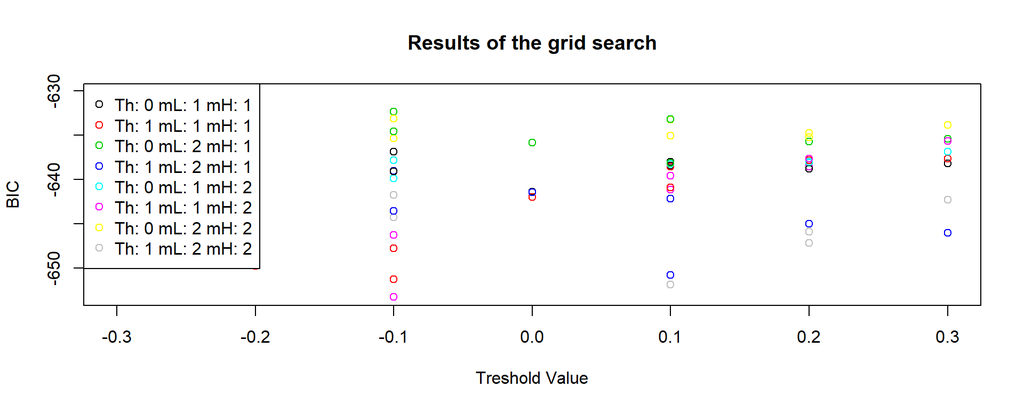

```
## Results of the grid search for 1 threshold
##    thDelay m   th       BIC
## 1        1 1 -0.1 -653.2390
## 2        1 2  0.1 -651.8608
## 3        1 1 -0.1 -651.2349
## 4        1 2  0.1 -650.7615
## 5        1 1 -0.2 -649.7445
## 6        1 1 -0.2 -649.0154
## 7        1 1 -0.1 -647.7634
## 8        1 2  0.2 -647.1349
## 9        1 1 -0.1 -646.2319
## 10       1 2  0.3 -645.9771
```

the estimated thDelay corresponds to d-1.

```r
tmp <- EstimSETAR(xt, 2, 1, -0.1)
tmp <- EstimSETAR_postproc(tmp)
str(tmp)
```

```
## List of 15
##  $ p          : num 2
##  $ d          : num 1
##  $ c          : num -0.1
##  $ data       : num [1:189] 0.3 0.1 0.2 0.1 -0.1 ...
##  $ n          : int 189
##  $ PhiParams  : num [1:6] 0.0676 0.8578 0.099 -0.0224 0.6647 ...
##  $ PhiStErrors: num [1:6] 0.01958 0.07962 0.05496 0.00756 0.04184 ...
##  $ residuals  : num [1:187, 1] 0.096 -0.0305 -0.184 -0.0311 -0.0719 ...
##  $ resSigmaSq : num 0.029
##  $ n1         : num 65
##  $ n2         : num 124
##  $ resSigmaSq1: num 0.0303
##  $ resSigmaSq2: num 0.0288
##  $ AIC        : num -651
##  $ BIC        : num -631
```

Note that we set `thDelay=0:(mmax-1)` instead of `1:mmax`. `selectSETAR` uses `thDelay = 0` for step `d=1` delay correspondence: `x(t-d) < c` or `x(t-d) > c`. the resulting BIC’s are different, possibly due to the package using a different formula

```r
mmax <- pmax
```

```r
par(mfrow=c(1,1))
( result2 <- selectSETAR(xt, m=mmax, thDelay=0:(mmax-1), criterion="BIC", same.lags=T, trim=0.1) )
```

```
## Using maximum autoregressive order for low regime: mL = 7
## Using maximum autoregressive order for high regime: mH = 7
## Searching on 20 possible threshold values within regimes with sufficient ( 10% ) number of observations
## Searching on  980  combinations of thresholds ( 20 ), thDelay ( 7 ) and m ( 7 )
```

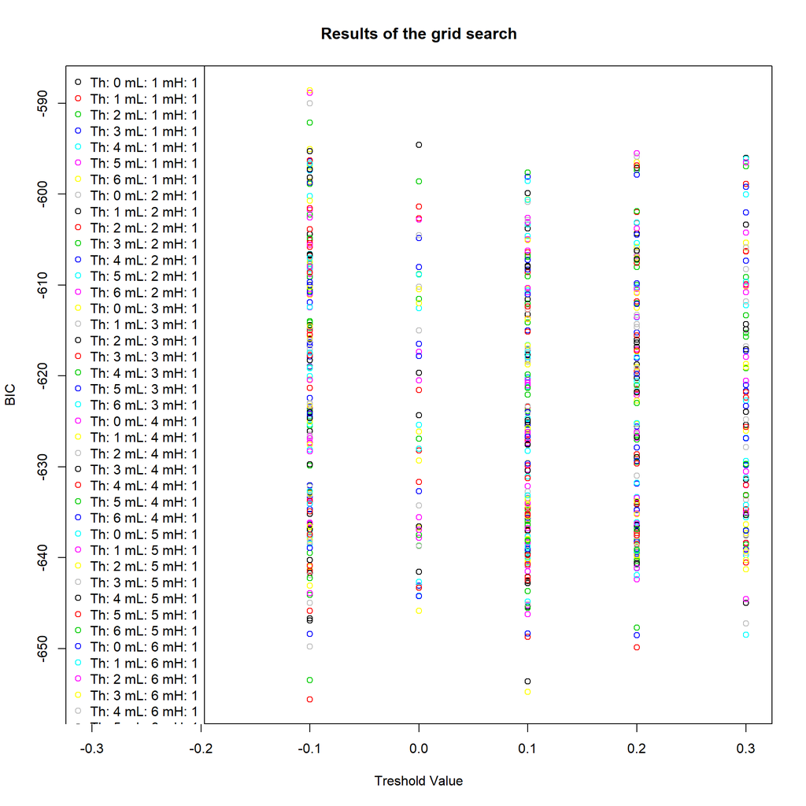

```
## Results of the grid search for 1 threshold
##    thDelay m   th       BIC
## 1        1 1 -0.1 -655.5737
## 2        1 2  0.1 -654.7770
## 3        1 2  0.1 -653.6045
## 4        1 1 -0.1 -653.4817
## 5        1 1 -0.2 -651.7920
## 6        1 1 -0.2 -651.0374
## 7        1 2  0.2 -649.8661
## 8        1 1 -0.1 -649.7745
## 9        4 2  0.1 -648.7036
## 10       1 2  0.2 -648.5209
```

Setting higher `mmax`, the function returns a list of models similar to the one given by our procedure in section 2.3. We can also compare the accuracy of the computation of the regression coefficients in our `EstimSETAR` method, with for example: `setar()` function (from `tsDyn` library as well):

```r
setars <- list()
coeffComparison <- list()
resSigmaComparison <- list()
n <- length(xt)
for (i in 1:3) {
  p <- models[[ orders[i] ]]$p
  d <- models[[ orders[i] ]]$d
  c <- models[[ orders[i] ]]$c
  setars[[i]] <- setar(xt, m=p)
  k <- max(p, d)
  resSigmaComparison[[i]] <- c(
    (1 / (n - k) * sum(setars[[i]]$residuals ^ 2)),
    models[[ orders[i] ]]$resSigmaSq
    )
  inbuiltParams <- t(setars[[i]]$coefficients)
  key <- paste(p, d, round(c, digits=4), sep=" / ")
  coeffComparison[[key]] <- rbind(
    inbuiltParams,
    t(append(models[[orders[i]]]$PhiParams, models[[orders[i]]]$c))
  )
  row.names(coeffComparison[[key]]) <- t(c("inbuilt", "custom"))
}
```

```
##
##  1 T: Trim not respected:  0.855615 0.144385 from th: 0.2
##  1 T: Trim not respected:  0.8540541 0.1459459 from th: 0.2
##  1 T: Trim not respected:  0.8548387 0.1451613 from th: 0.2
```

```r
coeffComparison
```

```
## $`2 / 2 / 0.1077`
##              const.L    phiL.1    phiL.2     const.H    phiH.1     phiH.2
## inbuilt -0.017760627 0.4484198 0.2619552 -0.03164651 0.9628571 -0.1110418
## custom   0.003935039 0.4470165 0.3746089  0.09138806 1.0802664 -0.4245433
##             th
## inbuilt 0.1000
## custom  0.1077
##
## $`4 / 1 / 0.3052`
##             const.L    phiL.1    phiL.2     phiL.3       phiL.4    const.H
## inbuilt -0.01991345 0.4542545 0.1739903 0.07360014 -0.001386634  0.1071890
## custom  -0.01041551 0.5253961 0.1957427 0.04672256 -0.029251020 -0.1503804
##            phiH.1    phiH.2      phiH.3     phiH.4     th
## inbuilt 0.4405088 0.6411567 -0.28578707 -0.3329385 0.2000
## custom  0.9452945 0.7317165 -0.00962392 -1.2916701 0.3052
##
## $`3 / 2 / 0.1077`
##              const.L    phiL.1    phiL.2     phiL.3    const.H    phiH.1
## inbuilt -0.019933012 0.4540914 0.1736989 0.07281194 0.05031824 0.6395189
## custom   0.004390532 0.4251347 0.3372253 0.07776119 0.08019403 1.0786974
##             phiH.2     phiH.3     th
## inbuilt  0.5246069 -0.5172980 0.2000
## custom  -0.3105694 -0.1179286 0.1077
```

```r
# comparing RSS

resSigmaComparison <- data.frame(matrix(unlist(resSigmaComparison), nrow=3, byrow=T))
colnames(resSigmaComparison) <- c("inbuilt", "custom")
row.names(resSigmaComparison) <- t(paste("rss",1:3))
resSigmaComparison
```

```
##         inbuilt     custom
## rss 1 0.0284493 0.02660428
## rss 2 0.0271898 0.02587450
## rss 3 0.0277478 0.02642112
```

### 2.6: Conclusion

The results of the SETAR Parameter Estimation Procedure in section 2.3 show that the 3 best 2-regime SETAR models are:

```
##           unlist.results.
## 1 SETAR( 2 , 2 , 0.1077 )
## 2 SETAR( 4 , 1 , 0.3052 )
## 3 SETAR( 3 , 2 , 0.1077 )
```

## 3: Tests of Linearity/Nonlinearity of SETAR models

We need to make sure a non-linear model (SETAR, for example) is really suitable for describing the process. In order to find out, we test the null hypothesis that a linear model is more suitable than a non-linear one. In the case of a 2-regime model we are looking for, so called, nuisance parameters, i.e.: `H0: Phi1 = Phi2` where `Phi1` and `Phi2` are the parameters of the low and the high regime respectively.

### 3.1: Hansen’s Conditions

Hansen proposed three conditions to test whether a SETAR model can be tested for linearity using the so called Likelihood-Ratio (LR) test:

```r
Hansen <- function(d, c, Phi) {
  p <- (length(Phi)/2) - 1
  Phi <- do.call(rbind, split(Phi,rep(1:2,each=(p + 1))))  #separate regimes into rows
  c1 <- !isTRUE(all.equal( 0, apply(Phi[,c(1,1 + d),drop=F],2, diff) %*% c(1,c) ))  # (p10-p20)+(p1d-p2d)*c <= 0
  c2 <- all(apply(Phi[,-c(1,1 + d),drop=F], 2, function(x) !identical(0, diff(x))))  # p1j neq p2j, j notin {0,d}
  c3 <- all(apply(Phi[,-1,drop=F], 1, function(x) sum(abs(x))) < 1)  # sum_j|pij| < 1 forall i=1,2
  c(cond1=c3, cond2=c2, cond3=c3)
}
```

If all three are satisfied the model can be tested using the LR test:

```r
hansenResults <- matrix(NA, ncol=3, nrow=12)
keys <- array()
for (i in 1:12) {
  p <- models[[ orders[i] ]]$p
  d <- models[[ orders[i] ]]$d
  c <- models[[ orders[i] ]]$c
  keys[i] <- paste(p, d, round(c, digits=4), sep=" / ")
  hansenResults[i,] <- Hansen(d, c, models[[ orders[i] ]]$PhiParams)
}
row.names(hansenResults) <- keys
colnames(hansenResults) <- c("cond1","cond2","cond3")

hansenResults
```

```
##                cond1 cond2 cond3
## 2 / 2 / 0.1077 FALSE  TRUE FALSE
## 4 / 1 / 0.3052 FALSE  TRUE FALSE
## 3 / 2 / 0.1077 FALSE  TRUE FALSE
## 2 / 1 / 0.4    FALSE  TRUE FALSE
## 1 / 1 / 0.005   TRUE  TRUE  TRUE
## 4 / 4 / 0.3052 FALSE  TRUE FALSE
## 5 / 1 / 0.3052 FALSE  TRUE FALSE
## 3 / 1 / 0.4    FALSE  TRUE FALSE
## 5 / 4 / 0.3052 FALSE  TRUE FALSE
## 4 / 2 / 0.1077 FALSE  TRUE FALSE
## 6 / 1 / 0.3052 FALSE  TRUE FALSE
## 5 / 2 / 0.4    FALSE  TRUE FALSE
```

### 3.2: LR and LM Tests

In this section we formulate the basic procedures for the LR (Likelihood Ratio), and LM (Lagrange Multiplier) tests:

```r
LRtest <- function(x, p, var, alpha=0.05) {
  tmp <- ar(x, aic=F, order.max=pmax, method = "ols")
  tmp <- tmp$var.pred  # linear model residual variance
  testat <- length(x)*(tmp-var)/tmp  # test statistic
  CDF <- Vectorize( function(t) {  # test statistic CDF
    fun <- function(t) 1 + sqrt(t/(2*pi))*exp(-t/8) + 1.5*exp(t)*pnorm(-1.5*sqrt(t)) - (t+5)*pnorm(-sqrt(t)/2)/2
    if(abs(t)>300 || is.infinite(t)) return(sign(t))
    if(t >=0 ) fun(t) else 1-fun(-t)
  })
  if(alpha==0.05) critval <- 7.68727553 # for alpha=2.5%: CV=11.03329250
  else critval <- uniroot(function(x) CDF(x) - (1-alpha), c(-1000,1000))$root
  c(TS=testat, CV=critval, p_value=1-CDF(testat))  # (test statistics, critical value, p-value)
}

LRtest(xt, models[[ orders[1] ]]$p, models[[ orders[1] ]]$resSigmaSq)
```

```
##           TS           CV      p_value
## 16.980295662  7.687275530  0.008177646
```

```r
suppressMessages(library(dynlm))

LMtest <- function(x, p, d, alpha = 0.05) {
  names(p) <- NULL   # prevent from passing (accidental and needless) name to result
  x <- as.ts(x)  # if x is not a ts object, by chance
  model1 <- dynlm(x ~ L(x,1:p))  # requires dynlm package (it can be implemented withou dynlm, see model2)
  y <- model1$residuals
  tmp <- c(  # a list of shifted time series
    list(y),
    lapply(1:p, function(i) stats::lag(x, -i)),
    lapply(1:p, function(i) stats::lag(x, -i)*stats::lag(x,-d)),
    list(stats::lag(x,-d)^3)
  )
  tmp <- do.call(function(...) ts.intersect(..., dframe=T), tmp)
  names(tmp) <- c("y", paste0("x",1:p), paste0("xd",1:p), "xd^3")
  model2 <- lm(y ~ ., data = tmp)  # cannot be done with the dynlm package
  z <- model2$residuals
  testat <- (length(x)-p) * (sum(y^2)/sum(z^2) - 1)
  c(TS=testat, CV=qchisq(1-alpha, df=p+1), p_value=1-pchisq(testat, df=p+1))
}

LMtest(xt, models[[ orders[1] ]]$p, models[[ orders[1] ]]$d)
```

```
##           TS           CV      p_value
## 1.670958e+01 7.814728e+00 8.108925e-04
```

We can easily automate the testing procedure in the following loop:

```r
alpha = 0.05
results <- list()
nonlinear <- list()
nonLinCount <- 0
for (i in 1:12) {
  p <- models[[ orders[i] ]]$p; d <- models[[ orders[i] ]]$d; c <- models[[ orders[i] ]]$c;
  hansenResult <- Hansen(d, c, models[[ orders[i] ]]$PhiParams)
  if (FALSE %in% hansenResult) {
    hansenResult <- FALSE
    testResult <- LMtest(xt, p, d)
  } else {
    hansenResult <- TRUE
    testResult <- LRtest(xt, p, models[[ orders[i] ]]$resSigmaSq)
  }
  if (testResult[3] < alpha) {
    nonLinCount <- nonLinCount + 1
    nonlinear[[nonLinCount]] <- models[[ orders[i] ]]
  }
  results[[i]] <- append(cbind(p, d, c, hansenResult), testResult)
}
results <- data.frame(matrix(unlist(results), nrow=12, byrow=T))
colnames(results) <- c("p", "d", "c", "Hansen Cond.", "TS", "CV", "p-value")
row.names(results) <- orders[1:12]
results[,4] <- as.logical(results[,4])

results
```

```
##    p d      c Hansen Cond.        TS        CV      p-value
## 3  2 2 0.1077        FALSE 16.709581  7.814728 0.0008108925
## 7  4 1 0.3052        FALSE 10.303332 11.070498 0.0670827796
## 5  3 2 0.1077        FALSE 16.907313  9.487729 0.0020147602
## 2  2 1 0.4000        FALSE  4.321514  7.814728 0.2287741088
## 1  1 1 0.0050         TRUE -1.496878  7.687276 0.7493100029
## 10 4 4 0.3052        FALSE  7.373623 11.070498 0.1943030316
## 11 5 1 0.3052        FALSE  8.858398 12.591587 0.1816996934
## 4  3 1 0.4000        FALSE  6.619573  9.487729 0.1574105391
## 14 5 4 0.3052        FALSE  7.987675 12.591587 0.2390076615
## 8  4 2 0.1077        FALSE 16.821155 11.070498 0.0048517734
## 16 6 1 0.3052        FALSE 16.306227 14.067140 0.0224612343
## 12 5 2 0.4000        FALSE 18.580085 12.591587 0.0049348331
```

[output not shown]

### 3.3 Modified LR Test Via Boostrapping

The proposed LR test has a significant drawback in the fact that it can only be done when Hansen’s conditions are satisfied. This is due to the fact that we do not know the distribution of the resulting F-statistic. According to Hansen (1996), however, the distribution of a bootstrapped statistic F* converges weakly in probability to the distribution of F, so that repeated bootstrap draws from F* can be used to approximate the asymptotic distribution of F.

To obtain F* we will make regressions of the time series `xt` and the multi-regime matrix `Xt`, where `y_star` will be the vector of dependent variables - a series of random values generated from N(0,1).

```r
library(matlib)

bootstrapSigmaSq1 <- function(x, y_star) {
  tilde_model <- lm(y_star ~ x, data=data.frame(x))
  return (sum((tilde_model$residuals - x)^2) / length(x))
}

bootstrapSigmaSq2 <- function(x, y_star, p, d, c) {
  n <- length(x); k <- max(p, d);

  X <- as.matrix(apply(as.matrix((k + 1):n), MARGIN=1, function(t) Xt(x, t, p, d, c) ))
  y <- as.matrix(y_star[(k + 1):n])

  A = crossprod(t(X), t(X));  b = crossprod(t(X), y)

  if (abs(det(A)) > 0.0001) {
    inv <- inv(A)
    params <- inv %*% b
    skel <- crossprod(X, params)
    residuals <- (y - skel)
    return(sum(residuals ^ 2)/ (n - k) )
  } else {
    return(NA)
  }
}

signif_code <- function(p_val) {
  return (
    ifelse(p_val < 0.1 && p_val >= 0.05, ".",
           ifelse(p_val < 0.05 && p_val >= 0.01, "*",
                  ifelse(p_val < 0.01 && p_val >= 0.001, "**",
                         ifelse(p_val < 0.001, "***", "")
                  )
           )
      )
  )
}

n <- length(xt)
n_draws <- 1000 # of bootstrap draws per threshold c
model_p_values <- list();
```

The following method processes a chunk of generated data from N(0,1)

```r
process_chunk <- function(chunk) {
  suppressMessages(library(matlib))
  n <- length(xt); n_chunk <- length(chunk) / n;
  y_stars <- split(chunk, cut(seq_len(n_chunk), n_chunk, labels = FALSE))
  count <- 0
  for (i in 1:n_chunk) {
    y_star <- y_stars[[i]]
    sigmaSqTilde <- bootstrapSigmaSq1(xt, y_star)
    sigmaSqHat <- bootstrapSigmaSq2(xt, y_star, p, d, c)
    FstatDraw <- (n * (sigmaSqTilde - sigmaSqHat) / sigmaSqHat)
    if (FstatDraw > Fstat) {
      count <- count + 1
    }
  }
  return(count)
}
```

This procedure will be parallelized and applied to a large ( `n`x`n_draws`) array of values. The test results for `Fstat` (from the LR test) and `FstatDraw` (bootstrapped), namely: `FstatDraw > Fstat` will be counted to approximate the asymptotic null distribution of `Fstat`.

```r
library(parallel)

for (i in 1:12) {
  p <- models[[ orders[i] ]]$p
  d <- models[[ orders[i] ]]$d
  c <- models[[ orders[i] ]]$c

  sigmaSq <- models[[ orders[i] ]]$resSigmaSq
  Fstat <- LRtest(xt, p, sigmaSq)[1]

  Ystars <- rnorm(n * n_draws)

  ncl = detectCores() - 1 # detecting CPU cores available for parallel processing

  chunks <- split(Ystars, cut(seq_len(n_draws), ncl, labels = FALSE)) # split the generated matrix

  cl = makeCluster(ncl)
  clusterExport(cl,
      c("bootstrapSigmaSq1", "bootstrapSigmaSq2", "p", "d", "c",
        "xt", "Xt", "Yt", "Indicator", "Fstat"), envir=environment())

  result <- parLapply(cl, chunks, process_chunk) # parallel counting of "successful" draws
  stopCluster(cl)

  draw_count <- sum(as.numeric(result))

  p_val <- draw_count / n_draws
  model_p_values[[i]] <- c(paste("(",p,",",d,",",round(c, digits=4),")"), p_val, signif_code(p_val))
}

bootstrap_results <- data.frame(matrix(unlist(model_p_values), nrow=12, ncol=3, byrow=T))
colnames(bootstrap_results) <- c("model","P-value","")
bootstrap_results
```

```
##                 model P-value
## 1  ( 2 , 2 , 0.1077 )   0.553
## 2  ( 4 , 1 , 0.3052 )   0.554
## 3  ( 3 , 2 , 0.1077 )   0.617
## 4     ( 2 , 1 , 0.4 )       1
## 5   ( 1 , 1 , 0.005 )       1
## 6  ( 4 , 4 , 0.3052 )   0.894
## 7  ( 5 , 1 , 0.3052 )   0.565
## 8     ( 3 , 1 , 0.4 )   0.985
## 9  ( 5 , 4 , 0.3052 )   0.779
## 10 ( 4 , 2 , 0.1077 )   0.744
## 11 ( 6 , 1 , 0.3052 )   0.524
## 12    ( 5 , 2 , 0.4 )   0.743
```

### 3.4 Visualisation of Non-Linear Models

From the results of the previous procedure, we will visualize the models for which the linearity null-hypothesis was rejected based on the LR and LM tests:

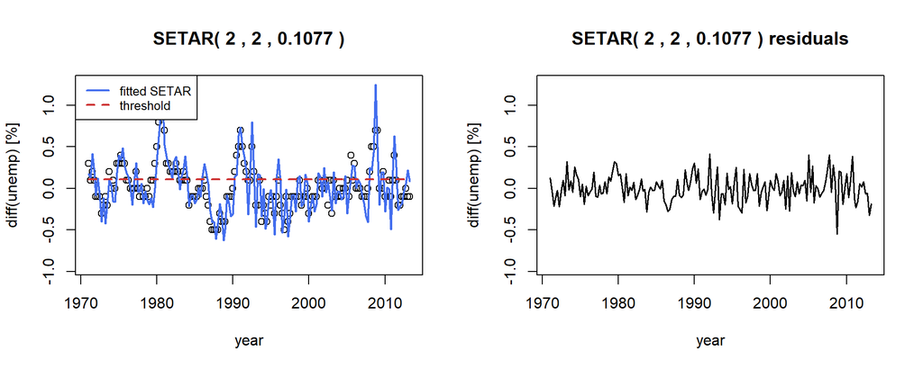

```
## resSigmaSq
## 0.02660428
```

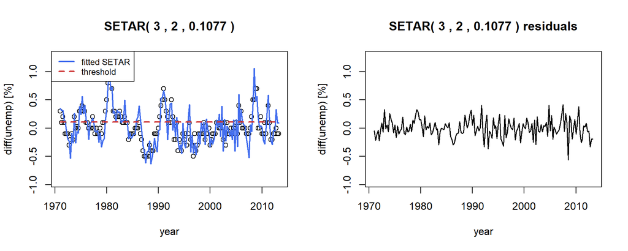

```
## resSigmaSq
## 0.02642112
```

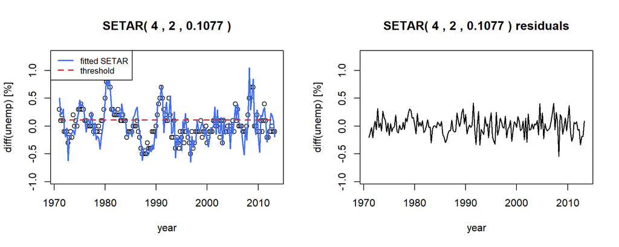

```
## resSigmaSq
## 0.02640513
```

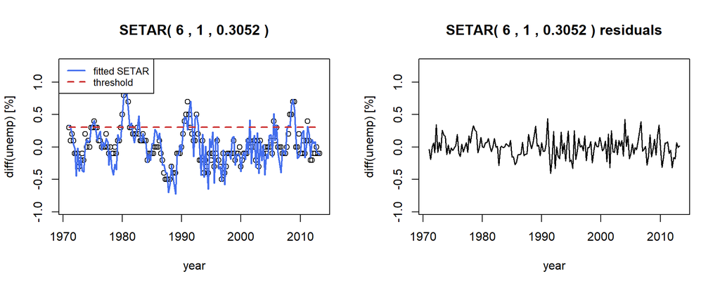

```
## resSigmaSq
##    0.02494
```

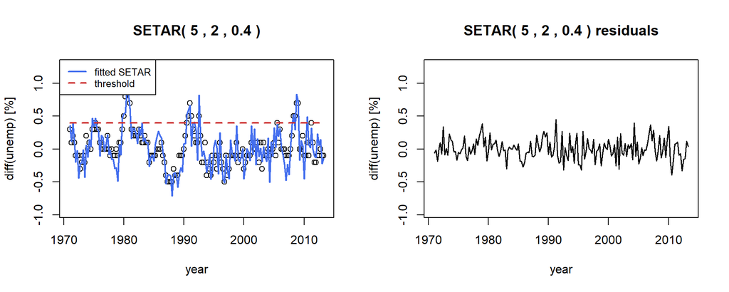

```
## resSigmaSq
##  0.0259558
```

```r
par(mfrow=c(1,2))
xmax <- max(xt); xmin <- min(xt) - 0.5 * xmax;
xmax <- xmax + 0.2 * (xmax - xmin)
for (i in 1:nonLinCount) {
  p <- nonlinear[[i]]$p
  d <- nonlinear[[i]]$d
  c <- nonlinear[[i]]$c
  x0 <- as.numeric(unempseries$test)[1]
  fitted <- xt[1:(N - L)] - nonlinear[[i]]$residuals[1:(N - L)]
  #diffsum <- sapply(1:(N - L), function(j) { x0 + sum(fitted[1:j]) })
  plot(x=dat$time[1:(N - L)], y=xt[1:(N - L)], ylim=c(xmin, xmax),
       main=paste("SETAR(",p,",",d,",",round(c, digits=4),")"),
       xlab="year", ylab="diff(unemp) [%]",type="p")
  lines(x=dat$time[1:(N - L)], y=fitted, lwd=2, col="royalblue2")
  lines(x=c(dat$time[1], dat$time[(N - L)]), y=c(c, c), col="brown3", lty="dashed", lwd=2)
  legend("topleft", legend=c("fitted SETAR","threshold"), col=c("royalblue2","brown3"), lty=c(1,2), lwd=2, cex=0.8)

  plot(x=dat$time[1:(N - L)], y=nonlinear[[i]]$residuals[1:(N - L)], type="l", lwd=1.5,
       main=paste("SETAR(",p,",",d,",",round(c, digits=4),") residuals"), xlab="year", ylab="diff(unemp) [%]", ylim=c(xmin, xmax))
  print( c(resSigmaSq = nonlinear[[i]]$resSigmaSq) )
}
```

## 4. 3-Regime SETARs and Diagnostic Tests of SETAR Models

The next step in the analysis using SETAR models is verifying whether 2 regimes suffice. If they do not, we will have to consider the possibility that a third regime needs to be added. In that case, we need to write methods for such model

### 4.1 Useful Functions

```r
# the indicator function for 3 regimes:
Indicator3 <- function(x, c) {
  tmp <- rep(F,3)
  tmp[findInterval(x, c, left.open = T) + 1] <- T
  tmp
}

Indicator3(-4, c(-1,1))
```

```
## [1]  TRUE FALSE FALSE
```

```r
Indicator3(0, c(-1,1))
```

```
## [1] FALSE  TRUE FALSE
```

```r
Indicator3(4, c(-1,1))
```

```
## [1] FALSE FALSE  TRUE
```

```r
# SETAR3 basis vector
Yt <- function(x, t, p) c(1, x[(t - 1):(t - p)])

# SETAR3 skeleton
Xt <- function(x, t, p, d, c, z = x) {
  # z is the threshold variable
  I <- Indicator3(z[t - d], c)
  Y <- Yt(x, t, p)
  c(I[1] * Y, I[2] * Y, I[3] * Y)
}

suppressMessages(library(matlib))

# covariance matrix of the 3 regime SETAR
CovMat3 <- function(x, p, d, c) {
  n <- length(x)
  Yc <- matrix(0., ncol = (3 * p + 3), nrow = (3 * p + 3)) # this will become the covariance matrix
  k <- max(p, d)
  for (t in (k + 1):n) {
    XT <- Xt(x, t, p, d, c)
    Yc <- Yc + (XT %o% XT)
  }
  det <- det(Yc)
  if (det > -0.00001 && det < 0.00001) {
    return(NA)
  } else {
    return(inv(Yc))
  }
}

CovMat3(xt, p=2, d=1, c=c(-0.1, 0.2))
```

```
##             [,1]       [,2]        [,3]        [,4]       [,5]        [,6]
##  [1,] 0.07248048  0.2302972  0.00215751  0.00000000  0.0000000  0.00000000
##  [2,] 0.23029715  1.1980070 -0.38034510  0.00000000  0.0000000  0.00000000
##  [3,] 0.00215751 -0.3803451  0.57098118  0.00000000  0.0000000  0.00000000
##  [4,] 0.00000000  0.0000000  0.00000000  0.01164245 -0.0209984  0.00331308
##  [5,] 0.00000000  0.0000000  0.00000000 -0.02099840  1.5909791 -0.30657670
##  [6,] 0.00000000  0.0000000  0.00000000  0.00331308 -0.3065767  0.38170432
##  [7,] 0.00000000  0.0000000  0.00000000  0.00000000  0.0000000  0.00000000
##  [8,] 0.00000000  0.0000000  0.00000000  0.00000000  0.0000000  0.00000000
##  [9,] 0.00000000  0.0000000  0.00000000  0.00000000  0.0000000  0.00000000
##              [,7]       [,8]        [,9]
##  [1,]  0.00000000  0.0000000  0.00000000
##  [2,]  0.00000000  0.0000000  0.00000000
##  [3,]  0.00000000  0.0000000  0.00000000
##  [4,]  0.00000000  0.0000000  0.00000000
##  [5,]  0.00000000  0.0000000  0.00000000
##  [6,]  0.00000000  0.0000000  0.00000000
##  [7,]  0.15071243 -0.3415514  0.06411848
##  [8,] -0.34155138  1.3811044 -0.73962398
##  [9,]  0.06411848 -0.7396240  0.77066336
```

```r
# skeleton of a model with regression coeffs: theta
SkeletonSETAR3 <- function(x, t, p, d, c, theta, z = x) c(theta %*% CovMat3(x, p, d, c)[t,])
SkeletonSETAR3(xt, t=3, p=2, d=1, c=c(-0.1, 0.2), rep(1, 3*3))
```

```
## [1] 0.1927936
```